# Week 44 Lecture 1

562770bf

2024-10-28

This is the first Rmd file for the Data Science and HR analytics course, trying out experiments on the code for lecture 1 in week 44.

So let’s get started.

```r
CEO_Diary <- read.csv("~/Dropbox/Mijn Mac (Macintosh.local)/Downloads/2017765data/behaviors/python_index-construction/baseline_results/survey_response_data.csv")
```

This command reads the csv file and calls the data in the table CEO Diary. The view command (not included as that does not work in a markdown file) just shows a visual overview of the data in a table.

```r
CEO_Diary[1:15,c(1:5,37, 39, 40)]
```

```
##     id finance mkting production strategy          type F_duration F_planned
## 1  607       0      1          0        0       meeting        1hr   planned
## 2  607       0      1          0        0       meeting        1hr   planned
## 3  607       0      1          0        0       meeting        1hr   planned
## 4  607       0      1          0        0       meeting        1hr   planned
## 5  607       0      1          1        0       meeting        1hr unplanned
## 6  607       0      1          1        0       meeting        1hr unplanned
## 7  607       0      1          1        0       meeting        1hr unplanned
## 8  607       0      1          1        0       meeting        1hr unplanned
## 9  607      NA     NA         NA       NA         email    1hrplus   planned
## 10 607      NA     NA         NA       NA         email    1hrplus   planned
## 11 607      NA     NA         NA       NA         email    1hrplus   planned
## 12 607      NA     NA         NA       NA         email    1hrplus   planned
## 13 607      NA     NA         NA       NA         email    1hrplus   planned
## 14 607      NA     NA         NA       NA         email    1hrplus   planned
## 15 607       0      1          0        0 business_meal        1hr   planned
```

This command shows a table of the previously inserted data, the first term shows the number of rows, 1 through 15 and the next term specifies the columns shown (1 through 5, 37, 39 and 40). Hence you can easily change the specifications to show a different number of rows and different variables as columns.

```r
CEO_Diary[1:7,c(6, 15, 21, 27, 35)]
```

```
##   hr it banks journalists out
## 1  0  0     0           0   1
## 2  0  0     0           0   1
## 3  0  0     0           0   1
## 4  0  0     0           0   1
## 5  0  0     0           0   0
## 6  0  0     0           0   0
## 7  0  0     0           0   0
```

```r
apply(CEO_Diary,2,class)
```

```
##             id        finance         mkting     production       strategy
##    "character"    "character"    "character"    "character"    "character"
##             hr         bunits          other          admin          board
##    "character"    "character"    "character"    "character"    "character"
##       chairman     compliance            coo            cao             it
##    "character"    "character"    "character"    "character"    "character"
##          legal         retail       groupcom        clients      suppliers
##    "character"    "character"    "character"    "character"    "character"
##          banks      investors        lawyers    consultants    politicians
##    "character"    "character"    "character"    "character"    "character"
##         govoff    journalists         unions         compts         others
##    "character"    "character"    "character"    "character"    "character"
##        dealers   associations      pemployee            ins            out
##    "character"    "character"    "character"    "character"    "character"
##    n_functions           type         level1     F_duration      F_planned
##    "character"    "character"    "character"    "character"    "character"
## F_participants   all_combined
##    "character"    "character"
```

The apply class command shows what sort of type the variables are, most of which are defined as string variables. The number 2 specifies that it will define the type for the columns. If you choose 1 instead of 2, it will do so for the rows. If you choose mean/max/min instead of class, it will define those values instead, which does not work here as most variables are all string variables.

```r
nrow(CEO_Diary)
```

```
## [1] 225721
```

```r
summary(CEO_Diary[1:5])
```

```
##        id            finance          mkting        production
##  Min.   :   1.0   Min.   :0.00    Min.   :0.00    Min.   :0.00
##  1st Qu.: 269.0   1st Qu.:0.00    1st Qu.:0.00    1st Qu.:0.00
##  Median : 521.0   Median :0.00    Median :0.00    Median :0.00
##  Mean   : 543.3   Mean   :0.17    Mean   :0.23    Mean   :0.35
##  3rd Qu.: 823.0   3rd Qu.:0.00    3rd Qu.:0.00    3rd Qu.:1.00
##  Max.   :1115.0   Max.   :1.00    Max.   :1.00    Max.   :1.00
##                   NA's   :98406   NA's   :98371   NA's   :98408
##     strategy
##  Min.   :0.00
##  1st Qu.:0.00
##  Median :0.00
##  Mean   :0.02
##  3rd Qu.:0.00
##  Max.   :1.00
##  NA's   :98414
```

```r
summary(CEO_Diary[5:10])
```

```
##     strategy           hr            bunits          other
##  Min.   :0.00    Min.   :0.00    Min.   :0.00    Min.   :0.00
##  1st Qu.:0.00    1st Qu.:0.00    1st Qu.:0.00    1st Qu.:0.00
##  Median :0.00    Median :0.00    Median :0.00    Median :0.00
##  Mean   :0.02    Mean   :0.08    Mean   :0.06    Mean   :0.05
##  3rd Qu.:0.00    3rd Qu.:0.00    3rd Qu.:0.00    3rd Qu.:0.00
##  Max.   :1.00    Max.   :1.00    Max.   :1.00    Max.   :1.00
##  NA's   :98414   NA's   :98412   NA's   :98414   NA's   :98316
##      admin           board
##  Min.   :0.00    Min.   :0.00
##  1st Qu.:0.00    1st Qu.:0.00
##  Median :0.00    Median :0.00
##  Mean   :0.04    Mean   :0.04
##  3rd Qu.:0.00    3rd Qu.:0.00
##  Max.   :1.00    Max.   :1.00
##  NA's   :98410   NA's   :98414
```

```r
summary(CEO_Diary[37])
```

```
##      type
##  Length:225721
##  Class :character
##  Mode  :character
```

The nrow command shows the number of rows in the data. The summary command shows a summary of the specified columns/variable range.

```r
  png(file="~/Dropbox/Mijn Mac (Macintosh.local)/Downloads/CEO_Types.png", width=800, height=300)
  par(mar=c(9, 3 ,1,1))
  barplot(prop.table(table(CEO_Diary$type)), las=2)
  dev.off()
```

The code above saves a PNG file showing the relative frequency of each CEO type in CEO_Diary$type. The barplot function plots proportions, and the las=2 argument rotates axis labels for readability.

```r
  table(CEO_Diary$type)
```

```
##
##       business_meal     conference_call               email             meeting
##                9459                4183               11880               94135
##               other     personal_family          phone_call        public_event
##                  62               21895                7075                2913
##          site_visit          travelling    video_conference       working_alone
##                7578               18950                 699               45336
## workrelated_leisure
##                1556
```

```r
  prop.table(table(CEO_Diary$type))
```

```
##
##       business_meal     conference_call               email             meeting
##        0.0419057155        0.0185317272        0.0526313458        0.4170413918
##               other     personal_family          phone_call        public_event
##        0.0002746754        0.0970002791        0.0313440043        0.0129053123
##          site_visit          travelling    video_conference       working_alone
##        0.0335724190        0.0839531989        0.0030967433        0.2008497216
## workrelated_leisure
##        0.0068934658
```

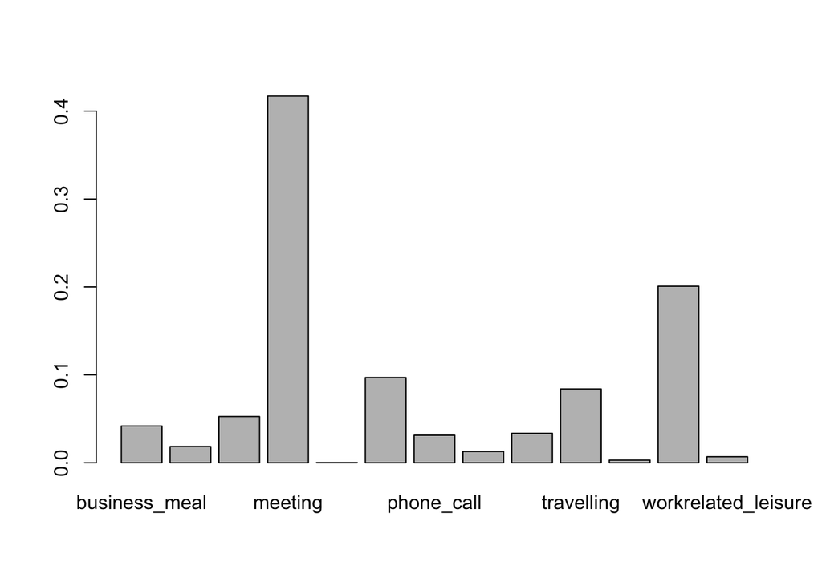

```r
  barplot(prop.table(table(CEO_Diary$type)))
```

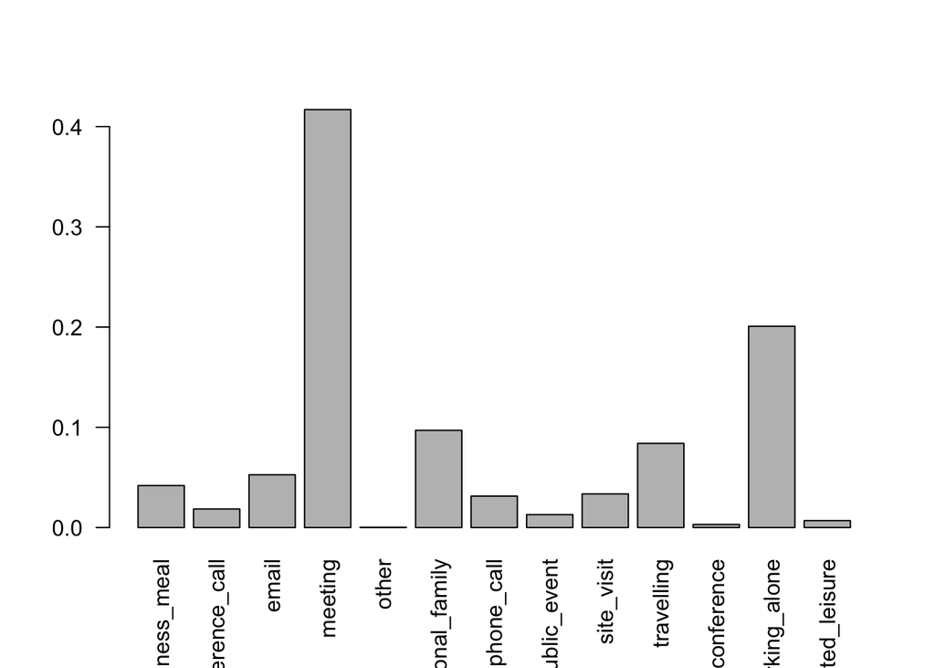

```r
  barplot(prop.table(table(CEO_Diary$type)), las=2)
```

The table command creates a frequency table for the type variable in the CEO_Diary dataset.The result shows the count of each unique value in the type column, helping you understand the distribution of CEO activity types. The prop.table converts the frequency counts into proportions, showing the relative frequency of each type category as a fraction of the total count (i.e., each category’s share in decimal form). The third line of code creates a bar plot of the proportions calculated in the previous step.Each bar represents a different type of CEO activity, with the bar height showing the proportion of that activity type relative to the total. The final line of code repeats the bar plot, but with las=2, which rotates the x-axis labels to be perpendicular to the axis. This rotation can make labels more readable if there are many categories or if the labels are lengthy.

```r
CEO_Diary <- read.csv("~/Dropbox/Mijn Mac (Macintosh.local)/Downloads/2017765data/behaviors/python_index-construction/baseline_results/survey_response_data.csv")
fit <- glm(strategy ~ consultants + politicians, data=CEO_Diary); summary(fit)
```

```
##
## Call:
## glm(formula = strategy ~ consultants + politicians, data = CEO_Diary)
##
## Coefficients:
##               Estimate Std. Error t value Pr(>|t|)
## (Intercept)  0.0239291  0.0004396  54.433  < 2e-16 ***
## consultants  0.0113590  0.0023339   4.867 1.13e-06 ***
## politicians -0.0241179  0.0053095  -4.542 5.57e-06 ***
## ---
## Signif. codes:  0 '***' 0.001 '**' 0.01 '*' 0.05 '.' 0.1 ' ' 1
##
## (Dispersion parameter for gaussian family taken to be 0.02357801)
##
##     Null deviance: 3002.6  on 127306  degrees of freedom
## Residual deviance: 3001.6  on 127304  degrees of freedom
##   (98414 observations deleted due to missingness)
## AIC: -115789
##
## Number of Fisher Scoring iterations: 2
```

This command fits a regression model, depending on the data type of strategy) where: strategy is the dependent variable or outcome.Consultants and politicians are the independent variables. ‘Data=CEO_Diary’ specifies that the data for this model comes from the CEO_Diary dataset. The glm term is a function for fitting generalized linear models, which includes a variety of model types (e.g., logistic regression for binary outcomes or linear regression for continuous outcomes).

```r
fit2 <- glm(strategy ~ govoff + unions, data=CEO_Diary); summary(fit2)
```

```
##
## Call:
## glm(formula = strategy ~ govoff + unions, data = CEO_Diary)
##
## Coefficients:
##               Estimate Std. Error t value Pr(>|t|)
## (Intercept)  0.0245360  0.0004362  56.254  < 2e-16 ***
## govoff      -0.0117717  0.0028990  -4.061  4.9e-05 ***
## unions      -0.0239419  0.0066535  -3.598  0.00032 ***
## ---
## Signif. codes:  0 '***' 0.001 '**' 0.01 '*' 0.05 '.' 0.1 ' ' 1
##
## (Dispersion parameter for gaussian family taken to be 0.02358077)
##
##     Null deviance: 3002.6  on 127306  degrees of freedom
## Residual deviance: 3001.9  on 127304  degrees of freedom
##   (98414 observations deleted due to missingness)
## AIC: -115774
##
## Number of Fisher Scoring iterations: 2
```

We get different estimates, both coefficients are now negative, but still small. However, hard to say anything useful here as there likely is no causal interpretation (significance of coefficients does not say that much about truth I think).